# 1. Introduction and Literature Review

### 3.2.2. Checking for stationarity

#### 3.2.2.1. Stationarity Check: Visual Method (First Lag Differences)

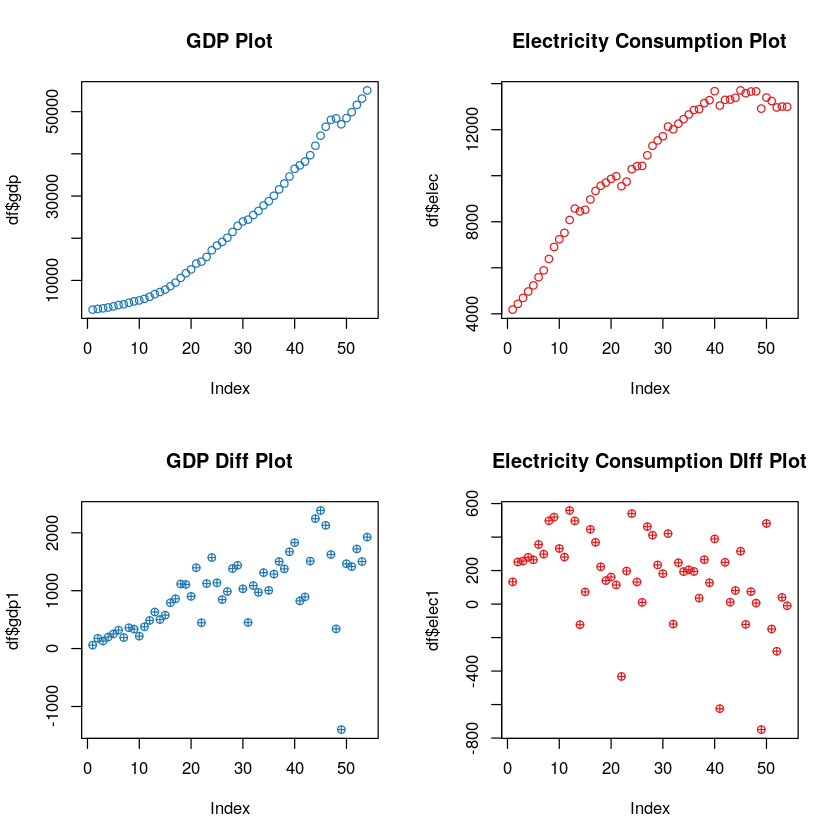

```r
## Creating grid for plots
par(mfrow=c(2,2))
## PLoting GDP
plot(df$gdp, col=myp[1], cex=01, pch=1, main="GDP Plot")
## Ploting elec
plot(df$elec, col=myp[2], cex=01, pch=1, main="Electricity Consumption Plot")
## PLoting GDP1
plot(df$gdp1, col=myp[1], cex=1, pch=10, main="GDP Diff Plot")
## Ploting elec1
plot(df$elec1, col=myp[2], cex=1, pch=10, main="Electricity Consumption DIff Plot")
```

#### 3.2.2.A. GDP Stationarity Check: ADF Method

```r
## Finding critical value for gdp1
ur.df(df$gdp1, type="drift")@cval[1,2]
```

-2.89

```r
## Finding actual T-value for gdp1
ur.df(df$gdp1, type="drift")
```

```
###############################################################
# Augmented Dickey-Fuller Test Unit Root / Cointegration Test #
###############################################################

The value of the test statistic is: -3.3569 5.7575
```

**On performing ADF test on GDP,we see that t value(-3.35) is to left of the critical value(-2.89), hence we can reject null hypothesis, thus this series is now made stationary and we can proceed for VAR modeling.**

#### 3.2.2.B. Electric Power Consumption Stationarity Check: ADF Method

```r
## Finding critical value for elec1
ur.df(df$elec1, type="drift")@cval[1,2]
```

-2.89

```r
## Finding actual T-value for elec1
ur.df(df$elec1, type="drift")
```

```
###############################################################
# Augmented Dickey-Fuller Test Unit Root / Cointegration Test #
###############################################################

The value of the test statistic is: -4.3814 9.6105
```

**On performing ADF test on Electrical Power Consumption,we see that t value(-4.38) is to left of the critical value(-2.89), hence we can reject null hypothesis, thus this series is now made stationary and we can proceed for VAR modeling.**

## 3.3. Creating VAR Models

```r
## Loadin vars lib fro VAR modeling
library(vars)
```

We expect that models selection based on following criteria will be listed

1. Akaike information criterion (AIC)
- Bayesian information criterion (BIC) or Schwarz criterion (SC)
- Final Prediction Error (FPE) criterion
- Hannan–Quinn information criterion (HQC)

```r
## Maaximum Lag=10, value can be changed is so desired.
## But after 10 year we do not belive any affects will remain.
maximum_lag=10
## Making list of models based on crriterias
model_list=VARselect(df[,3:4], lag.max = maximum_lag, type="const")
## Lisiting all models
model_list
```

**$selection**

**AIC(n)**

3

**HQ(n)**

1

**SC(n)**

1

**FPE(n)**

3

**$criteria**

|  | 1 | 2 | 3 | 4 | 5 | 6 | 7 | 8 | 9 | 10 |
| --- | --- | --- | --- | --- | --- | --- | --- | --- | --- | --- |
| AIC(n) | 2.383581e+01 | 2.389433e+01 | 2.380797e+01 | 2.387869e+01 | 2.401040e+01 | 2.415297e+01 | 2.421911e+01 | 2.420639e+01 | 2.430348e+01 | 2.417458e+01 |
| HQ(n) | 2.392603e+01 | 2.404471e+01 | 2.401850e+01 | 2.414937e+01 | 2.434123e+01 | 2.454395e+01 | 2.467025e+01 | 2.471768e+01 | 2.487492e+01 | 2.480617e+01 |
| SC(n) | 2.407910e+01 | 2.429983e+01 | 2.437567e+01 | 2.460858e+01 | 2.490249e+01 | 2.520726e+01 | 2.543561e+01 | 2.558509e+01 | 2.584437e+01 | 2.587767e+01 |
| FPE(n) | 2.248759e+10 | 2.387989e+10 | 2.198056e+10 | 2.373914e+10 | 2.735187e+10 | 3.200878e+10 | 3.490723e+10 | 3.543670e+10 | 4.050652e+10 | 3.733802e+10 |

## 3.4. Selecting VAR Models (Information Criteria)

The choice of selecting particular information criteria is out of scope of our study, we simply choose Schwarz criterion (SC) most commonly known as BIC.

```r
## Selecting model recommended by SC
model_list$selection[3]
```

**SC(n):** 1

On the basis of selecting SC we obtain a single model of type lag 1 which can be used to study Granger Causality.

## 3.5. Running model with lag length from selection.

```r
## Running the model with lag 1 as suggested by SC criterion.
model_1=VAR(df[,3:4], p=1, type="const")
```

# 4. Results & Analysis

## 4.1. Running model summary

```r
## Listing complete summary of model
summary(model_1)
```

```
VAR Estimation Results:
=========================
Endogenous variables: gdp1, elec1
Deterministic variables: const
Sample size: 53
Log Likelihood: -768.842
Roots of the characteristic polynomial:
0.7425 0.06223
Call:
VAR(y = df[, 3:4], p = 1, type = "const")


Estimation results for equation gdp1:
=====================================
gdp1 = gdp1.l1 + elec1.l1 + const

         Estimate Std. Error t value Pr(>|t|)
gdp1.l1    0.6105     0.1105   5.524 1.19e-06 ***
elec1.l1  -0.5961     0.2729  -2.185 0.033640 *
const    504.0983   131.7192   3.827 0.000362 ***
---
Signif. codes:  0 ‘***’ 0.001 ‘**’ 0.01 ‘*’ 0.05 ‘.’ 0.1 ‘ ’ 1


Residual standard error: 530.2 on 50 degrees of freedom
Multiple R-Squared: 0.3987,	Adjusted R-squared: 0.3746
F-statistic: 16.58 on 2 and 50 DF,  p-value: 3.003e-06


Estimation results for equation elec1:
======================================
elec1 = gdp1.l1 + elec1.l1 + const

          Estimate Std. Error t value Pr(>|t|)
gdp1.l1   -0.14895    0.05381  -2.768  0.00789 **
elec1.l1   0.06973    0.13286   0.525  0.60198
const    295.27492   64.13489   4.604 2.87e-05 ***
---
Signif. codes:  0 ‘***’ 0.001 ‘**’ 0.01 ‘*’ 0.05 ‘.’ 0.1 ‘ ’ 1


Residual standard error: 258.2 on 50 degrees of freedom
Multiple R-Squared: 0.1337,	Adjusted R-squared: 0.09909
F-statistic:  3.86 on 2 and 50 DF,  p-value: 0.02762



Covariance matrix of residuals:
        gdp1 elec1
gdp1  281157 58321
elec1  58321 66656

Correlation matrix of residuals:
       gdp1 elec1
gdp1  1.000 0.426
elec1 0.426 1.000
```

**We can make following conclusion after running model**

**4.1.A.** For GDP equation: $ gdp = gdp_{1} + elec_{1} + const $

*Hence, GDP is dependent both on lag of itself and lag of electricity power consumption.*

**4.1.B.** For Electrical power consumption equation: $ elec = gdp_1 + elec_1 + const$

1. $gdp_1$ is significant.
- $elec_1$ is insignificant and can be ignored.
- $const$ is significant.

The above analysis can be done in better way by using Granger Causality test. Hence

## 4.2. Running Granger Causality test.

### 4.2.1. Electric Power Consumption affects GDP.

Does electric power consumption affects GDP? We run the test with following assumption derived from section 1.2.1. Literature Review:

```
    H0: Electricity does not Granger causes GDP growth.
    H1: Electricity Granger causes GDP growth.
```

```r
### Running casuality test elec->gdp
causality(model_1, cause = "elec1")$Granger
```

```
	Granger causality H0: elec1 do not Granger-cause gdp1

data:  VAR object model_1
F-Test = 4.7721, df1 = 1, df2 = 100, p-value = 0.03126
```

### 4.2.1. GDP affects Electric Power Consumption .

Does GDP affects electric power consumption? We run the test with following assumption derived from section **1.2.2.** Literature Review:

[output not shown]

```r
causality(model_1, cause = "gdp1")$Granger
```

```
	Granger causality H0: gdp1 do not Granger-cause elec1

data:  VAR object model_1
F-Test = 7.6615, df1 = 1, df2 = 100, p-value = 0.006723
```

Since, p-value is less than 0.05 we can reject the null hypothesis that GDP does not affects the electric power consumption, hence, GDP affects the electric power consumption moreover the same can be concluded from **4.1.B.**.

# 5. Conclusion

While **4.1.A. & 4.1.B.** was sufficient enough to derive our conclusion but we still carried out Granger Causality test which gave same results.

In short we conclude that:

# 6. Implication & Recommendation

An alternative way is thus not to give discounts on electricity but to make electricity available to more people and use the funds for other factor explaining standard of leaving.